# KDPI and EPTS

# 1. KDRI and KDPI

## 1.1 Introduction

In the field of kidney transplantation, evaluating the quality of donor kidneys is crucial due to the persistent shortage of available organs. Two important indices have been developed to assess donor quality: the **Kidney Donor Risk Index (KDRI)** and the **Kidney Donor Profile Index (KDPI)**.

## 1.2 The Kidney Donor Risk Index (KDRI)

### 1.2.1 Definition and Purpose

The KDRI is a continuous metric that quantifies the relative risk of graft failure, which was defined as return to dialysis, reâ€‘transplant, or death, after kidney transplantation from a deceased donor. It provides a way to compare donor kidneys based on clinical and demographic factors.

### 1.2.2 Origin and Reference

The KDRI model was first proposed by **Rao etÂ al.Â (2009)** in the journal *Transplantation*$^{1}$. It is based on a multivariable **Cox proportional hazards model** that estimated the hazard of graft loss or death after transplantation. Global model fit was calculated using discrimination (concordance = 0.6, also known as the C-statistic) and calibration (Integrated Brier score = 0.13).

### 1.2.3 Model Formula

The stratified Cox model underlying the KDRI is

$$h(t \mid \mathbf Z, s) \,=\, h_{0,s}(t)\,
\exp(\boldsymbol\beta^{\!\top}\mathbf Z),$$

where

- $\mathbf Z = (Z_1,\ldots,Z_p)$ is the covariate vector for the $p=8$ donor factors listed in SectionÂ 1.2.4;
- $s$ indexes the stratum determined by **transplant centre**, **singleâ€‘year recipient age**, and **recipient diabetes status**. (not straified by OPO)
- $h_{0,s}(t)$ is the baseline hazard in stratumÂ $s$.

Hence, the **Kidney Donor Risk Index** for donorÂ $i$ is

$$\text{KDRI}_i\;=\;\frac{h(t\mid \mathbf Z_i)}{h(t\mid \mathbf
Z_{\text{ref}})}
\,=\, \exp\!\Bigl\{\boldsymbol\beta^{\!\top}(\mathbf Z_i-\mathbf
Z_{\text{ref}})\Bigr\}
\,=\,\prod_{j=1}^{p}
\mathrm{HR}_j^{\,Z_{ij}-Z_{\text{ref},j}},\qquad \mathrm{HR}_j \equiv
e^{\beta_j}.$$

### 1.2.4 Model Variables

RaoÂ *etÂ al.* initially included **10 donor factors**. In the current OPTN operational model (approved OctoberÂ 2024) this has been streamlined to **8 donor factors**:

1. Donor ageÂ (yrs)
2. Donor heightÂ (cm)
3. Donor weightÂ (kg)
4. History of hypertensionÂ (yes/no)
5. History of diabetesÂ (yes/no)
6. Cause of deathÂ (cerebrovascular accidentÂ vsÂ other)
7. Serum creatinineÂ (mg/dL)
8. Donation after cardiac death (DCD, yes/no)

*Black race* and *hepatitisÂ C virus (HCV) seropositivity* were removed during the 2024 refit.

### 1.2.5 Model Dataset

The latest refit used graft outcomes from **50 769** adult, first‑time, deceased‑donor kidney‑alone transplants performed in the United States between **2018Â andÂ 2021** (follow‑up through JuneÂ 2024).

### 1.2.6 Reference Donor Definition

The **reference donor** (KDRIÂ =Â 1.0) has:

- AgeÂ 40Â yr
- HeightÂ 170Â cm
- WeightÂ $\ge$Â 80Â kg
- No diabetes
- No hypertension
- Cause of death other than cerebrovascular accident
- Terminal creatinineÂ =Â 1.0Â mg/dL
- Brainâ€‘death donor (notÂ donation after cardiac death)

All other donors are compared against this reference profile.

### 1.2.7 Estimated Coefficients (OPTNÂ 2024, C-statistics = 0.6)

| Donor Factor | Column Names (*tx_ki*) | AppliesÂ toÂ Donors | $\hat\beta\times$CovariateÂ Shift |
| --- | --- | --- | --- |
| Age (yrs) | DON_AGE | All | 0.0092 × (AgeÂ -Â 40) |
|  |  | AgeÂ <Â 18 | 0.0113 × (AgeÂ -Â 18) |
|  |  | AgeÂ >Â 50 | 0.0067 × (AgeÂ -Â 50) |
| Height (cm) | DON_HGT_CM | All | -0.0557 × (HgtÂ -Â 170)/10 |
| Weight (kg) | DON_WGT_KG | WeightÂ <Â 80 | -0.0333 × (WgtÂ -Â 80)/5 |
| History of hypertension | DON_HTN | Yes | 0.1106 |
| History of diabetes | DON_HIST_DIAB | Yes | 0.2577 |
| Cause of deathÂ =Â CVA | DON_CAD_DON_COD | Yes | 0.0743 |
| Serum creatinine (mg/dL) | DON_CREAT | All | 0.2128 × (CreatÂ -Â 1.0) |
|  |  | CreatÂ >Â 1.5 | -0.2199 × (CreatÂ -Â 1.5) |
| DCD Status | DON_NON_HR_BEAT | Yes | 0.1966 |

> **Abbreviations:** CVA, cerebrovascular accident.

#### Old version of estimated model (Jul 2009)

| Donor Factor | Column Names (*tx_ki*) | Applies to Donors | $\hat\beta\times$CovariateÂ Shift |
| --- | --- | --- | --- |
| Age (yrs) | DON_AGE | All | 0.0128 × (AgeÂ -Â 40) |
|  |  | Age < 18 | -0.0194 × (AgeÂ -Â 18) |
|  |  | Age > 50 | 0.0107 × (AgeÂ -Â 50) |
| Height (cm) | DON_HGT_CM | All | -0.0464 × (HgtÂ -Â 170)/10 |
| Weight (kg) | DON_WGT_KG | Weight < 80 | -0.0199 × (WgtÂ -Â 80)/5 |
| Ethnicity | CAN_RACE_SRTR | African American | 0.1790 |
| History of hypertension | DON_HTN | Yes | 0.1260 |
| History of diabetes | DON_HIST_DIAB | Yes | 0.1300 |
| Cause of death = CVA | DON_CAD_DON_COD | Yes | 0.0881 |
| Serum creatinine (mg/dL) | DON_CREAT | All | 0.2200 × (CreatÂ -Â 1.0) |
|  |  | Creat > 1.5 | -0.2090 × (CreatÂ -Â 1.5) |
| HCV positive | DON_ANTI_HCV | Yes | 0.2400 |
| DCD Status | DON_NON_HR_BEAT | Yes | 0.1330 |

### 1.2.8 Model History

| Date | Version | Key Changes | Adoption Status |
| --- | --- | --- | --- |
| Jul, 2009 | Original KDRI (RaoÂ etÂ al.) | 14‑factor Cox model on 1995–2005 data; 10‑factor donor‑only version for allocation. | **Adopted**$^{1}$ |
| Dec, 2014 | KAS rollout of **KDPI** | 2009 coefficients mapped onto 2010 donor KDRI distribution; no refit. | Adopted |
| Aug, 2019 | Academic reevaluation | Re‑estimated on 2000–2016 data; minimal performance gain; not adopted. | Not adopted |
| Oct, 2024 | **Refit KDRI** | Refit on 2018–2021 data; removed race &Â HCV; updated KDPI mapping. | **Adopted** |

### 1.2.9 K-M Survival Plot by KDPI from OPTN

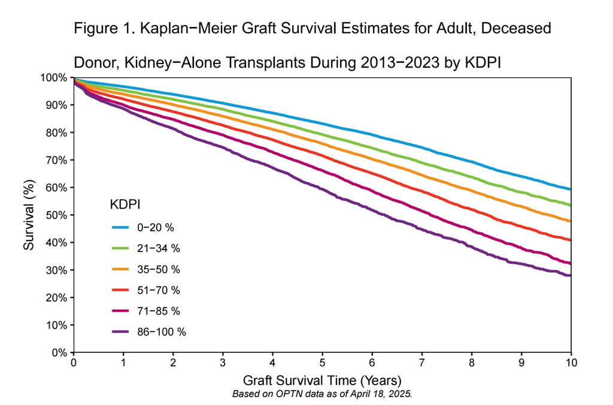

### 1.2.10 Applicability

KDRI applies only to **deceased donors**. Livingâ€‘donor analogues such as the **Living Kidney Donor Profile Index (LKDPI)**$^{5}$ are *not* used for allocation.

## 1.3 The Kidney Donor Profile Index (KDPI)

### 1.3.1 Definition

KDPI is defined as the **percentile rank (0–100%)** of a donor kidney’s Scaled KDRI against the U.S. donor pool from the previous calendar year.

### 1.3.2 Calculation

First calaulate the Scaled KDRI using the following formular.

$$\mathrm{KDRI}_{\text{SCALED}} =
\frac{\mathrm{KDRI}_{\text{RAO}}}{\text{scaling factor}}$$

The “scaling factor” is the median $\mathrm{KDRI}_{\text{RAO}}$ value among all kidney donors recovered during the previous calendar year (e.g.Â *scaling factor* = 1.404 in 2024).

Let $F_{\text{year}}$ be the empirical cumulative distribution function (CDF) of Scaled KDRI values for deceased donors in a given reference year. Then

$\text{KDPI} = 100\% \times F_{\text{year}}(\mathrm{KDRI}_{\text{SCALED}}).$

### 1.3.3 Annual Reference Distribution

- The 2024 OPTN guide illustrates KDPI using **2022** donor data$^{2}$.
- The most recent public mapping file is based on **2023** donors$^{3}$.

Hence KDPI reflects year‑to‑year changes in donor risk.

### 1.3.4 Worked Example

A donor with **KDRIÂ =Â 1.51** lies at the **90th percentile** of the 2023 donor distribution : **KDPIÂ =Â 90%**.

### 1.3.5 Evaluation of KDPI (C-Index)

The predictive power of the KDPI is moderate of C-Index = 0.6.

# 2. EPTS: Estimated Postâ€‘Transplant Survival Score

## 2.1 Definition and Purpose

The **Estimated Post‑Transplant Survival (EPTS)** score (0–100%) estimates how long a candidate is expected to live after transplantation. Lower scores imply longer expected survival. Kidneys with **KDPIÂ $\le$Â 20%** are offered first to candidates with **EPTSÂ $\le$Â 20%**.

## 2.2 Origin

Developed by the **Scientific Registry of Transplant Recipients (SRTR)** for the OPTN Kidney Committee$^{4}$.

## 2.3 Usage Conditions

- Applies only to adult candidates ($\ge$ 18 yr).
- Priority rule: **KDPIÂ $\le$ 20%** kidneys â†’ candidates with **EPTSÂ $\le$ 20%**.

## 2.4 Raw EPTS Formula

$$\begin{aligned}
\text{Raw EPTS} =\ & 0.047 \times \max(\text{Age} - 25,\ 0) - 0.015
\times \text{Diabetes} \times \max(\text{Age} - 25,\ 0) \\
& + 0.398 \times \text{Prior Solid Organ Transplant} - 0.237 \times
\text{Diabetes} \times \text{Prior Organ Transplant} \\
& + 0.315 \times \log(\text{Years on Dialysis} + 1) - 0.099 \times
\text{Diabetes} \times \log(\text{Years on Dialysis} + 1) \\
& + 0.130 \times I(\text{Years on Dialysis} = 0) - 0.348 \times
\text{Diabetes} \times I(\text{Years on Dialysis} = 0) + 1.262 \times
\text{Diabetes}
\end{aligned}$$

- `log()` denotes the natural logarithm.
- IndicatorÂ $I(\cdot)$ equalsÂ 1 if the condition is true, otherwiseÂ 0.
- Binary covariates `Diabetes` and `PriorÂ Tx` take valueÂ 1 when present andÂ 0 otherwise.

The final **EPTS score** is the percentile of the raw score within the national adult wait‑list on **31 DecÂ 2023** (updated annually).

## 2.5 Model Variables

The four predictors in the original Cox model were: **age**, **diabetes**, **prior transplant history**, and **dialysis duration**.

## 2.6 Model History

OPTN is exploring a **Composite Allocation Score (CAS)** that aggregates ten attributes—KDPI/EPTS matching, waiting time, geography, HLA, etc.—into a single 0–100 scale.

## 2.7 Interpretation

- EPTSÂ =Â 0%Â : longest expected survival
- EPTSÂ =Â 100%Â : shortest expected survival
- **EPTSÂ $\le$ 20%** triggers priority for **KDPIÂ $\le$ 20%** kidneys.

### 2.8 K-M Survival Plot by EPTS from OPTN

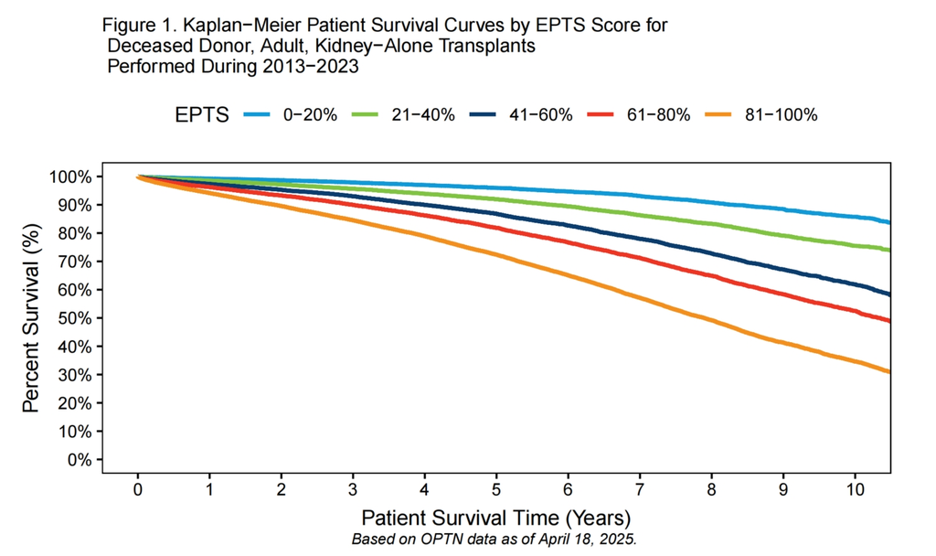

# References

> 1. Rao PS, Schaubel DE, Guidinger MK, et al.Â A Comprehensive Risk Quantification Score for Deceased Donor Kidneys: The Kidney Donor Risk Index. *Transplantation*. 2009;88(2):231-236.
> 2. OPTN. A Guide to Calculating and Interpreting the Kidney Donor Profile Index (KDPI). Updated: October 10, 2024. https://optn.transplant.hrsa.gov/media/j34dm4mv/kdpi_guide.pdf
> 3. OPTN. KDRI to KDPI Mapping Table. https://optn.transplant.hrsa.gov/media/wnmnxxzu/kdpi_mapping_table.pdf
> 4. OPTN. A Guide to Calculating and Interpreting the Estimated Post-Transplant Survival (EPTS) Score Used in the Kidney Allocation System (KAS). Updated: April 17, 2024. https://optn.transplant.hrsa.gov/media/pn1pt2bc/epts_guide.pdf
> 5. Massie, A. B., Leanza, J., Fahmy, L. M., Chow, E. K., Desai, N. M., Luo, X., King, E. A., Bowring, M. G., & Segev, D. L. (2016). A Risk Index for Living Donor Kidney Transplantation. American journal of transplantation : official journal of the American Society of Transplantation and the American Society of Transplant Surgeons, 16(7), 2077â€“2084. https://doi.org/10.1111/ajt.13709
> 6. OPTN Minority Affairs Committee. Refit kidney donor profile index without race and hepatitis C virus. Published online 2024. Organ Procurement and Transplantation Network. Accessed October 9, 2024. https://optn.transplant.hrsa.gov/media/0zamk0dr/mac_kdpi_board-briefing-paper.pdf
> 7. Zhong, Y., Schaubel, D. E., Kalbfleisch, J. D., Ashby, V. B., Rao, P. S., & Sung, R. S. (2019). Reevaluation of the Kidney Donor Risk Index. Transplantation, 103(8), 1714â€“1721. https://doi.org/10.1097/TP.0000000000002498
> 8. OPTN. EPTS Mapping Table. https://optn.transplant.hrsa.gov/media/g3xfajp4/epts_mapping_table.pdf
> 9. Snyder, J. J., Salkowski, N., Kim, S. J., Zaun, D., Xiong, H., Israni, A. K., & Kasiske, B. L. (2016). Developing Statistical Models to Assess Transplant Outcomes Using National Registries: The Process in the United States. *Transplantation*, 100(2), 288â€“294. https://doi.org/10.1097/TP.0000000000000891